# BT1101-Tutorial 4 (Part 2 Deadline: 26 Sept 9am)

## Preparation

```r
# install required packages if you have not (suggested packages: dplyr, tidyr, rpivotTable, knitr, psych)
# install.packages("dplyr") #only need to run this code once to install the package
# load required packages
# library("xxxx")
library("dplyr") #need to call the library before you use the package
library("tidyr")
library("rpivotTable")
library("knitr")
library("psych")
library(readxl)
```

### Tutorial 4 Part 2 (To be submitted - 30 Marks)

- Dataset required: `ds_salaries.csv`

The dataset contains Data Science jobs salary data aggregated by ai-jobs.net. There are 607 observations and 11 variables. Each of the variable (column) is defined as follows:

- `work_year`: The year the salary was paid.
- `experience_level`: The experience level in the job during the year with the following possible values: EN Entry-level / Junior; MI Mid-level / Intermediate; SE Senior-level / Expert; EX Executive-level / Director
- `employment_type`: The type of employment for the role: PT Part-time; FT Full-time; CT Contract; FL Freelance
- `job_title`: The role worked in during the year.
- `salary`: The total gross salary amount paid.
- `salary_currency`: The currency of the salary paid as an ISO 4217 currency code.
- `salary_in_usd`: The salary in USD (FX rate divided by avgerage USD rate for the respective year via fxdata.foorilla.com).
- `employee_residence`: Employee’s primary country of residence during the work year as an ISO 3166 country code.
- `remote_ratio`: The overall amount of work done remotely, possible values are as follows: 0 No remote work (less than 20%); 50 Partially remote; 100 Fully remote (more than 80%)
- `company_location`: The country of the employer’s main office or contracting branch as an ISO 3166 country code.
- `company_size`: The average number of people that worked for the company during the year: S less than 50 employees (small); M 50 to 250 employees (medium); L more than 250 employees (large)

```r
#import dataset into RStudio

ds <- read.csv("~/Downloads/ds_salaries.csv")
```

As a business analytics analyst, you are required to perform the following tasks as described in each question below.

### Q2.(a) Descriptive Statistics for `salary_in_usd` (9 marks)

In the previous tutorial, you have examined the frequency distributions of the `salary_in_usd` variable. You would like to learn more about this variable by examining the descriptive statistics. Create a table displaying n (or number of observations), mean, standard deviation, median, skew, and kurtosis. Can you describe the distribution of this variable based on the statistics? (4 marks)

Can you plot a chart and table that provides a visualisation of the mean `salary_in_usd` for different employment types and another chart and table of mean `salary_in_usd` for different experience levels? Describe your observations from these charts? (5 marks)

(For Tutorial discussion: plot a density plot, normal Q-Q plot, and compare these plots with the histogram you have plotted in tutorial 3 as well as the observations you have just made from the descriptive statistics)

**BEGIN: YOUR ANSWER**

```r
### Table displaying n, mean, sd, med, skew, kurtosis for salary_in_usd
ds.salaryinusd <- describe(ds$salary_in_usd)
ds.salaryinusd <- ds.salaryinusd %>% select(!c(trimmed,mad,range,min,max,se))
ds.salaryinusd$vars <- c("Salary in USD")
kable(ds.salaryinusd, row.names=FALSE, caption = "Distribution of Salary in USD data")
```

Distribution of Salary in USD data

| vars | n | mean | sd | median | skew | kurtosis |
| --- | --- | --- | --- | --- | --- | --- |
| Salary in USD | 607 | 112297.9 | 70957.26 | 101570 | 1.659312 | 6.261119 |

```r
###Visualisation of the mean 'salary_in_usd' for different employment types
ds.mean_employ <- ds %>% select(employment_type, salary_in_usd) %>%
  group_by(employment_type) %>%
  summarise(mean_salary_in_usd = mean(salary_in_usd))
kable(ds.mean_employ, caption = "Mean Salary in USD for different employment types")
```

Mean Salary in USD for different employment types

| employment_type | mean_salary_in_usd |
| --- | --- |
| CT | 184575.0 |
| FL | 48000.0 |
| FT | 113468.1 |
| PT | 33070.5 |

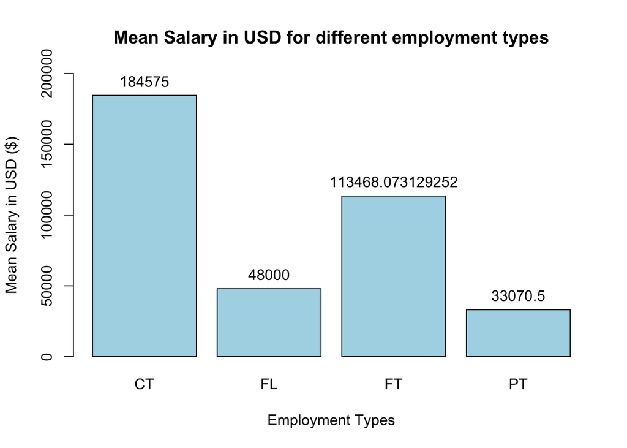

```r
bpemployment <- barplot(ds.mean_employ$mean_salary_in_usd, main = "Mean Salary in USD for different employment types",  names.arg =ds.mean_employ$employment_type, ylim = c(0,200000), xlab="Employment Types", ylab="Mean Salary in USD ($)", col = "light blue")
text(ds.mean_employ$mean_salary_in_usd, x=bpemployment, col="black", ds.mean_employ$mean_salary_in_usd, pos=3)
```

```r
###Visualisation of the mean 'salary_in_usd' for different experience levels
ds.mean_exp <- ds %>% select(experience_level, salary_in_usd) %>%
  group_by(experience_level) %>%
  summarise(mean_salary_in_usd = mean(salary_in_usd))
kable(ds.mean_exp, caption = "Mean Salary in USD for different experience levels")
```

Mean Salary in USD for different experience levels

| experience_level | mean_salary_in_usd |
| --- | --- |
| EN | 61643.32 |
| EX | 199392.04 |
| MI | 87996.06 |
| SE | 138617.29 |

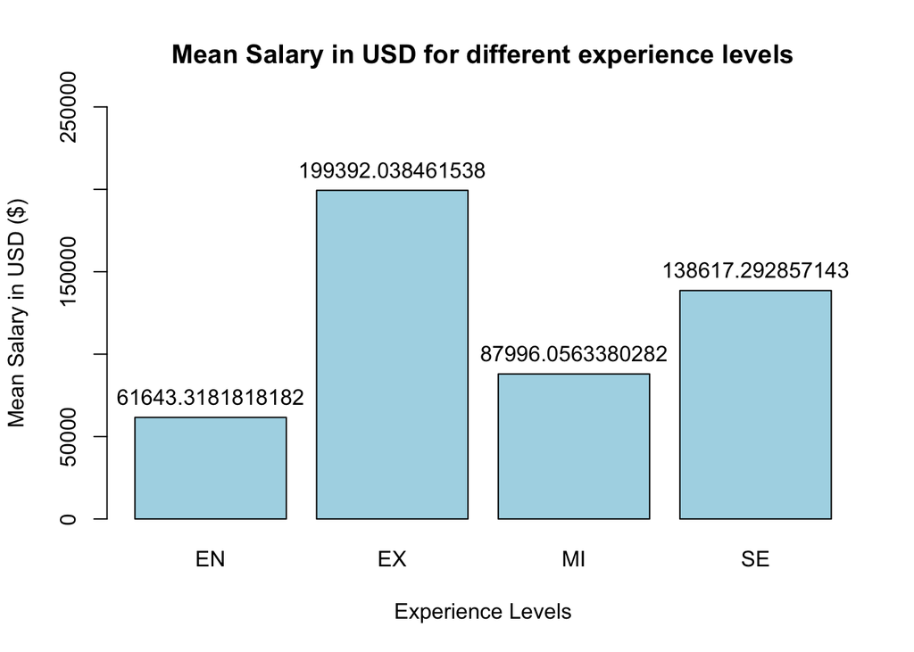

```r
barplot(ds.mean_exp$mean_salary_in_usd, main = "Mean Salary in USD for different experience levels",  names.arg =ds.mean_exp$experience_level, ylim = c(0,250000), xlab="Experience Levels", ylab="Mean Salary in USD ($)", col = "light blue")
text(ds.mean_exp$mean_salary_in_usd, x=bpemployment, col="black", ds.mean_exp$mean_salary_in_usd, pos=3)
```

**END: YOUR ANSWER**

### Q2.(b) Outlier Analyses for `salary_in_usd` (19 marks)

In the last tutorial, you examined the frequency distributions for employment_type and experience_level. According to industry practice, it is common for salaries to vary across different employment type and experience level. For example, full time employees are usually paid more than part time employees because of the number of hours worked; full-time employment tends to have a different salary structure compared to contract and free-lance work arrangement; higher levels of work experience also confer higher salaries and executive-level directors may be paid more compared to entry or mid-level/intermediate level employees.

- 1. Generate a histogram of `salary_in_usd` for each employment_type. Type what you observe below. (3 marks)
- 2. Given full-time employment is very different from the other employment types, and forms the majority of the data, you have decided to analyse it separately. Keeping only the observations where employment_type is “FT”, plot a histogram of `salary_in_usd` for each experience_level. For each histogram, do a visual inspection to determine whether any outliers exist. Type what you observe below.(4 marks)
- 3. You are told that the `salary_in_usd` variable for full time senior level/ expert roles approximates normal distribution. Could you use the boxplot method to identify if there are any mild or extreme outliers? Type the values of the outliers (if any) below. (5 marks)
- 4. Again, keeping only the data comprising full-time senior level/ expert employment, remove any outliers (even mild ones) if any based on your findings in 2b(iii). Plot the histogram, density plot and normal Q-Q plot for `salary_in_usd` and conduct the Shapiro Wilk’s test on `salary_in_usd`. Explain if `salary_in_usd` for full-time senior level/ expert employment employees is normally distributed. (7 marks)

**BEGIN: YOUR ANSWER**

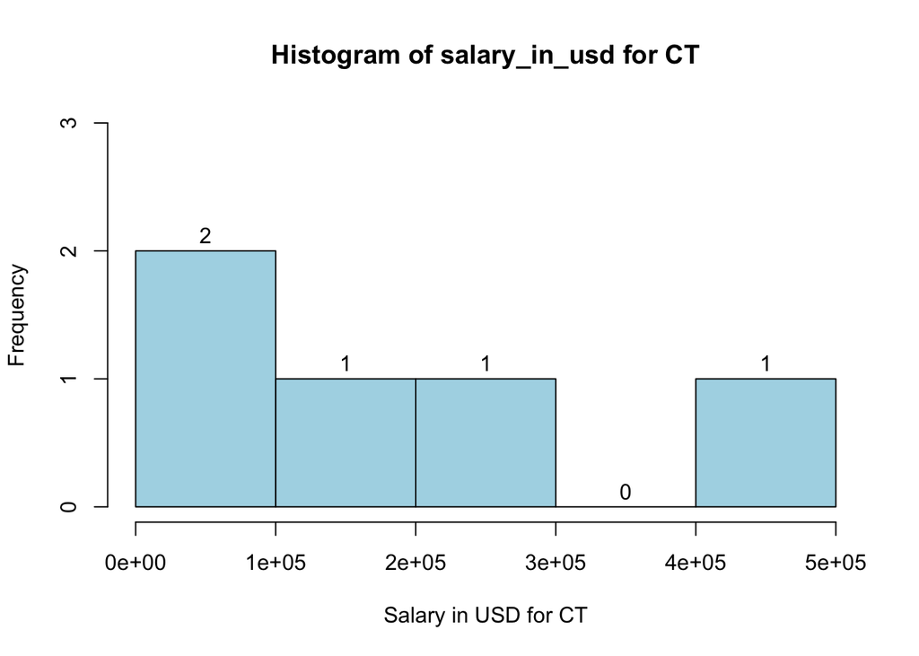

```r
######bi
###Histogram of salary_in_usd for CT
ds.ct_salary <- ds %>% filter(employment_type=='CT')
hist(ds.ct_salary$salary_in_usd, main='Histogram of salary_in_usd for CT', xlab='Salary in USD for CT',col='light blue', labels =TRUE,  ylim = c(0,3))
```

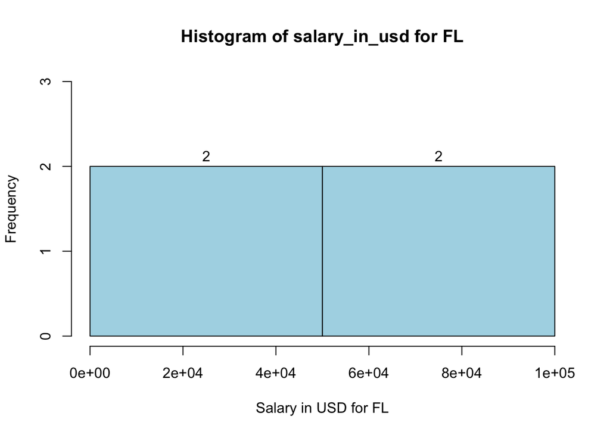

```r
###Histogram of salary_in_usd for FL
ds.ct_salary <- ds %>% filter(employment_type=='FL')
hist(ds.ct_salary$salary_in_usd, main='Histogram of salary_in_usd for FL', xlab='Salary in USD for FL',col='light blue', labels =TRUE,  ylim = c(0,3))
```

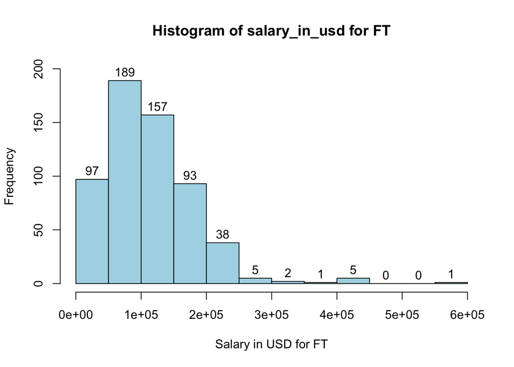

```r
###Histogram of salary_in_usd for FT
ds.ct_salary <- ds %>% filter(employment_type=='FT')
hist(ds.ct_salary$salary_in_usd, main='Histogram of salary_in_usd for FT', xlab='Salary in USD for FT',col='light blue', labels =TRUE, ylim = c(0,200))
```

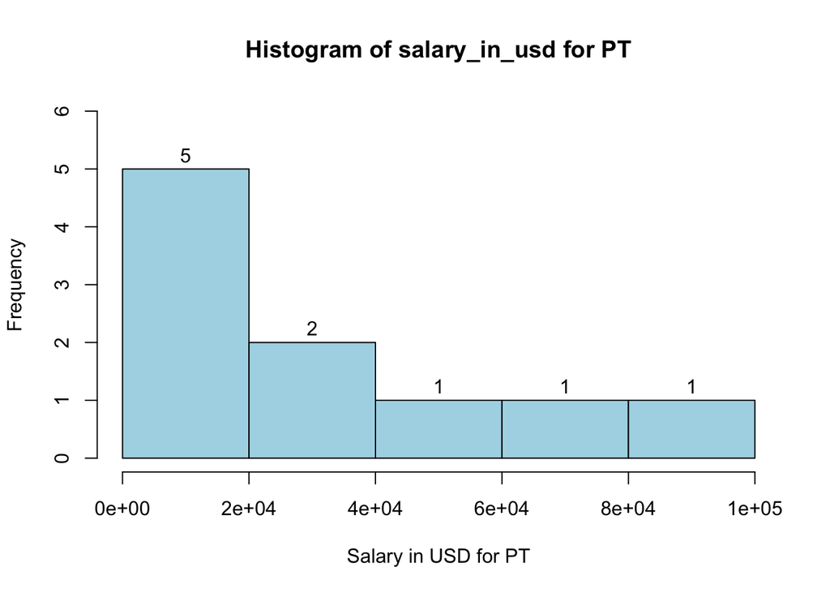

```r
###Histogram of salary_in_usd for PT
ds.ct_salary <- ds %>% filter(employment_type=='PT')
hist(ds.ct_salary$salary_in_usd, main='Histogram of salary_in_usd for PT', xlab='Salary in USD for PT',col='light blue', labels =TRUE,  ylim = c(0,6))
```

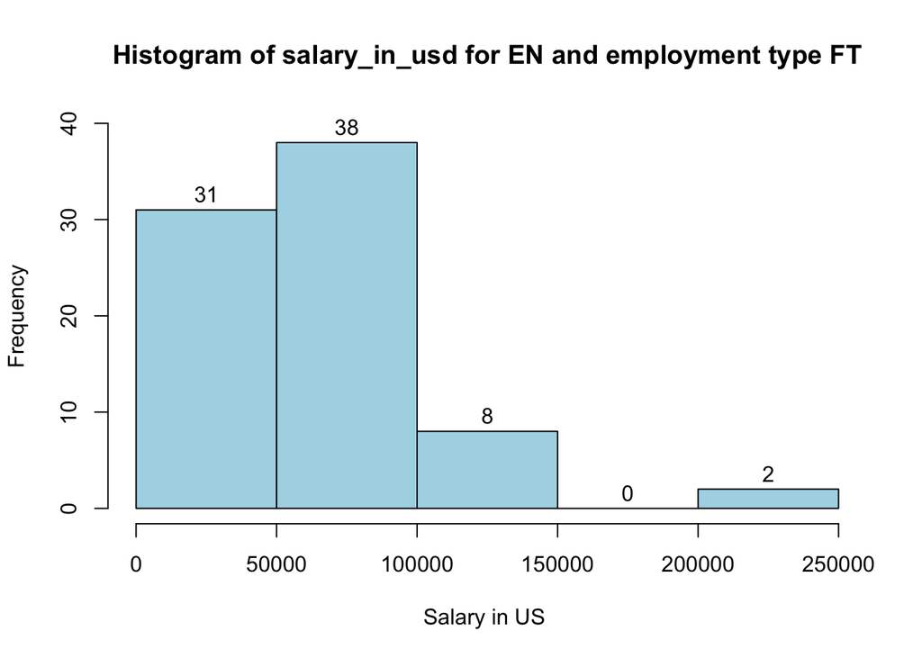

```r
######bii
###Histogram of salary_in_usd for FT and EN
ds.ft_en_salary <- ds %>% filter(employment_type=='FT', experience_level=="EN")
hist(ds.ft_en_salary$salary_in_usd, main='Histogram of salary_in_usd for EN and employment type FT', xlab='Salary in US ',col='light blue', ylim=c(0,40), labels = TRUE)
```

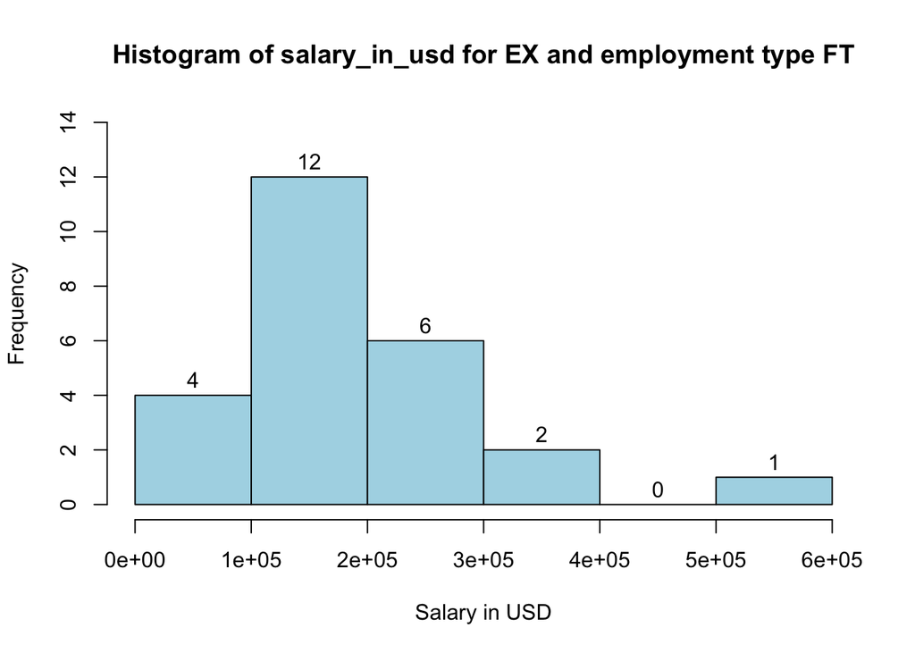

```r
###Histogram of salary_in_usd for FT and EX
ds.ft_ex_salary <- ds %>% filter(employment_type=='FT', experience_level=="EX")
hist(ds.ft_ex_salary$salary_in_usd, main='Histogram of salary_in_usd for EX and employment type FT', xlab='Salary in USD',col='light blue', ylim=c(0,14), labels = TRUE)
```

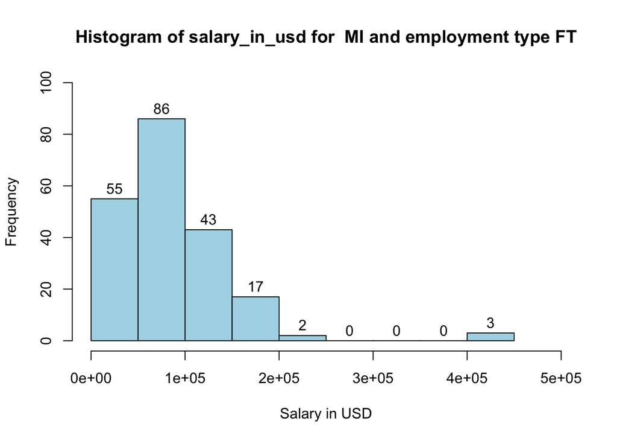

```r
###Histogram of salary_in_usd for FT and MI
ds.ft_mi_salary <- ds %>% filter(employment_type=='FT', experience_level=="MI")
hist(ds.ft_mi_salary$salary_in_usd, main='Histogram of salary_in_usd for  MI and employment type FT', xlab='Salary in USD',col='light blue', ylim=c(0,100), xlim= c(0,500000), labels = TRUE)
```

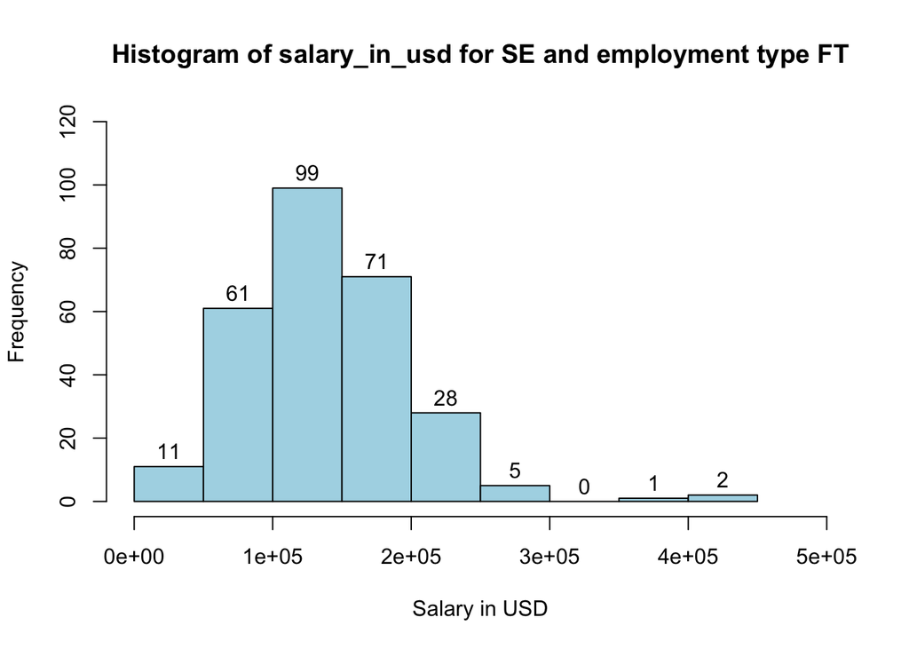

```r
###Histogram of salary_in_usd for FT and SE
ds.ft_se_salary <- ds %>% filter(employment_type=='FT', experience_level=="SE")
hist(ds.ft_se_salary$salary_in_usd, main='Histogram of salary_in_usd for SE and employment type FT', xlab='Salary in USD',col='light blue', ylim=c(0,120), xlim= c(0,500000), labels = TRUE)
```

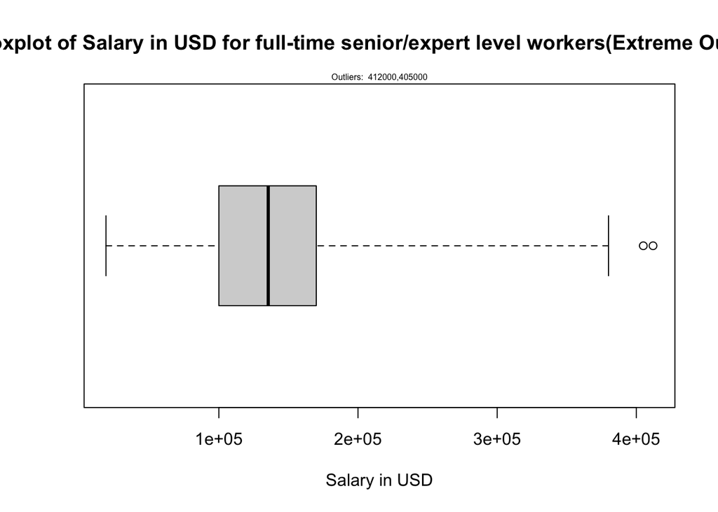

```r
######biii boxplot for FT, SE
ds.biii <- ds %>% filter(experience_level == 'SE')
bp1 <- boxplot(ds.biii$salary_in_usd, main = "Boxplot of Salary in USD for full-time senior/expert level workers(Extreme Outliers)", xlab = "Salary in USD", range = 3, horizontal = TRUE)
out1 <- bp1$out
mtext(paste("Outliers: ", paste(out1, collapse =',')), cex = 0.5)
```

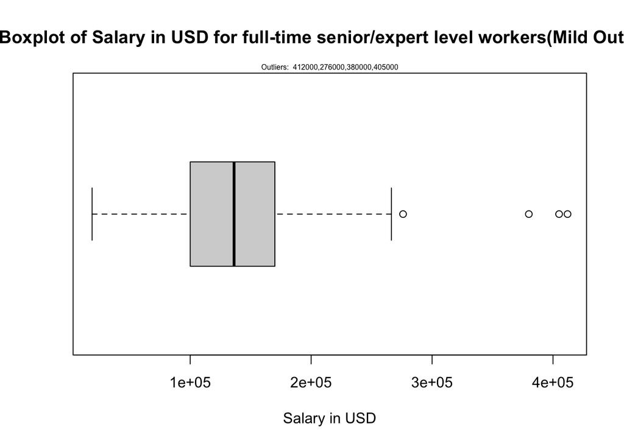

```r
ds.biii <- ds %>% filter(experience_level == 'SE', employment_type == "FT")
bp2 <- boxplot(ds.biii$salary_in_usd, main = "Boxplot of Salary in USD for full-time senior/expert level workers(Mild Outliers", xlab = "Salary in USD", range = 1.5, horizontal = TRUE)
out2 <- bp2$out
mtext(paste("Outliers: ", paste(out2, collapse =',')), cex = 0.5)
```

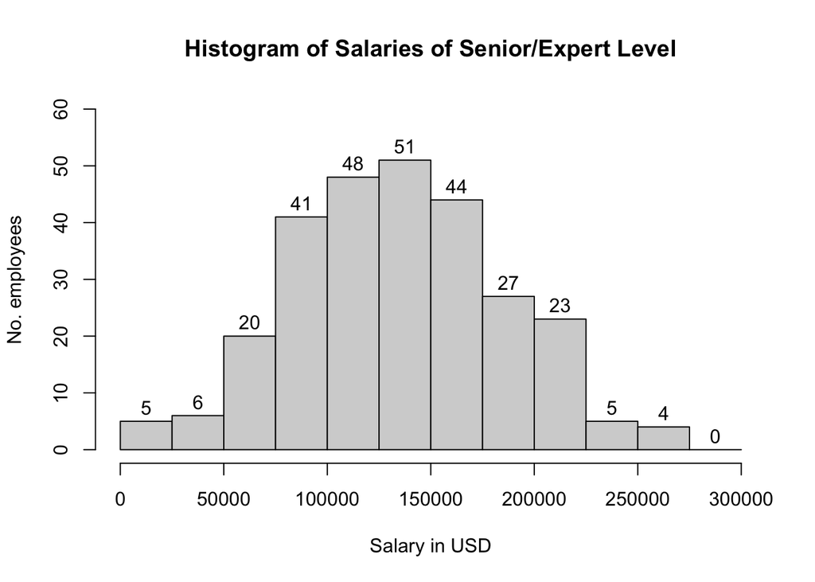

```r
######biv

###Removing outliers+ histogram
outliers <- which(ds.biii$salary_in_usd%in% c(out2))
edited_ds =ds.biii[-outliers,]
breaks <- seq(0,300000, by=25000)
hist(edited_ds$salary_in_usd,labels=TRUE,main="Histogram of Salaries of Senior/Expert Level",xlab="Salary in USD",ylab="No. employees",ylim=c(0,60), xlim = c(0,300000), breaks=breaks)
```

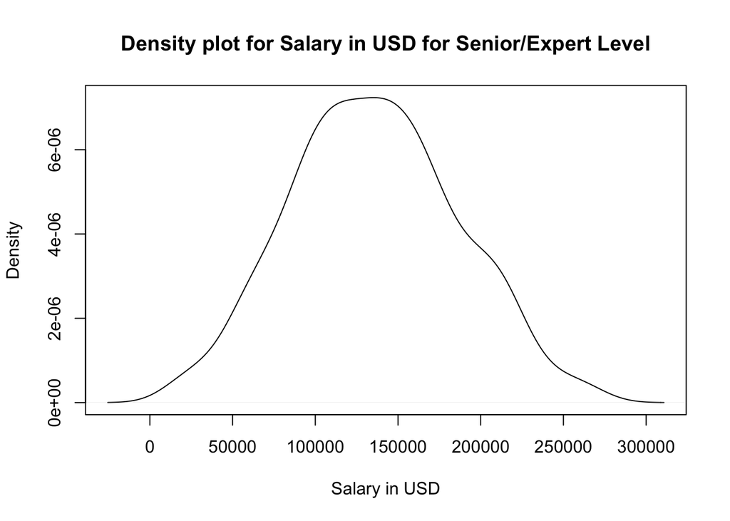

```r
###density plot
plot(density(edited_ds$salary_in_usd), main = "Density plot for Salary in USD for Senior/Expert Level", xlab = "Salary in USD")
```

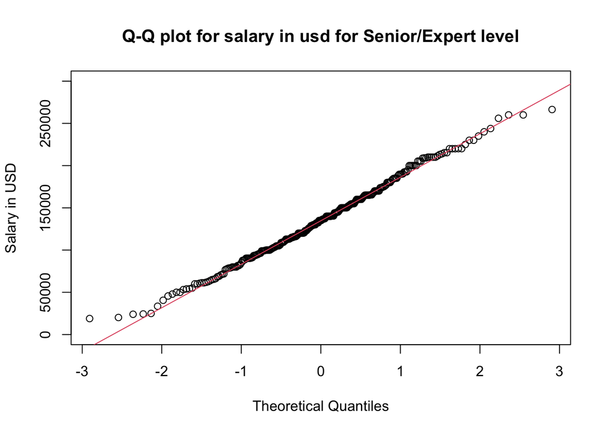

```r
###q-q plot
qqnorm(edited_ds$salary_in_usd,  ylim = c(0,300000), main = "Q-Q plot for salary in usd for Senior/Expert level", ylab = "Salary in USD")
qqline(edited_ds$salary_in_usd, col = 2,)
```

```r
###Shapiro Wilk Test
shapiro.test(edited_ds$salary_in_usd)
```

```
##
##  Shapiro-Wilk normality test
##
## data:  edited_ds$salary_in_usd
## W = 0.99411, p-value = 0.3654
```

Type your answer here.

- 1. Observations from histograms: Distribution of salary_in_usd is mostly uniform for CT and FL while that of FT and PT is positively skewed. Thus the data is not normally distributed
- 2. Data is not normally distributed. For EN: Outliers are those earning between $200000 and $250000 For EX: Outliers are those earning between $500000 and $600000 For MI: Outliers are those earning between $400000 and $450000 For SE: Outliers are those earning between $350000 and $450000
- 3. Considering range=3, extreme outliers: 412000, 405000 Considering range=1.5, mild outliers:276000, 380000 All outliers: 276000, 380000, 405000, 412000
- 4. As the p-value of 0.3654 > 0.05, it implies that the distribution of thae data is not significantly different from normal distribution and that the data does not deviate from normality.

**END: YOUR ANSWER**

### Q2.(c) Computing proportions and probabilities (2 marks)

- 1. Using the data from 2b(iv), compute the proportion of full time senior level/expert employees who are Data Scientist. (1 mark)
- 2. Given that `salary_in_usd` is a random variable that is normally distributed with mean of 135600 and standard deviation of 50500, what is the probability of `salary_in_usd` being less than $110,000. (1 mark)

**BEGIN: YOUR ANSWER**

```r
######ci - compute proportion of se who are data scientist
se_total <- nrow(edited_ds)
filter_ds<- edited_ds %>% filter(job_title == "Data Scientist")
se_ds <- nrow(filter_ds)
prop <- se_ds/se_total
prop
```

```
## [1] 0.2189781
```

```r
######cii salaryuss: mean = 135600, sd = 50500, salary <110000
pnorm(110000, 135600,50500)
```

```
## [1] 0.3061017
```

Type your answer here.

- 1. Proportion is 0.2189781.
- 2. Probability that salary_in_usd < 110000 is 0.3061017.

**END: YOUR ANSWER**